# Graphics with ggplot2

Alok K. Shukla

12/11/2016

Sample dataset.

```r
housing <- read.csv("dataSets/landdata-states.csv")
head(housing[1:5])
```

```
##   State region  Date Home.Value Structure.Cost
## 1    AK   West 20101     224952         160599
## 2    AK   West 20102     225511         160252
## 3    AK   West 20093     225820         163791
## 4    AK   West 20094     224994         161787
## 5    AK   West 20074     234590         155400
## 6    AK   West 20081     233714         157458
```

## `ggplot2` VS Base for simple graphs

Base graphics histogram example:

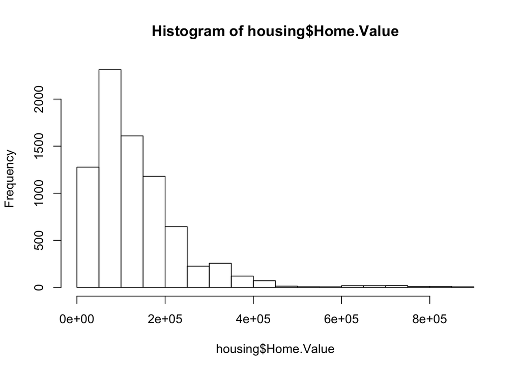

```r
  hist(housing$Home.Value)
```

`ggplot2` histogram example:

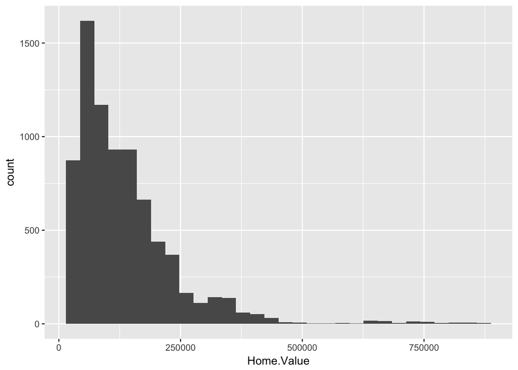

```r
  ggplot(housing, aes(x = Home.Value)) +
    geom_histogram()
```

`ggplot2` Base graphics VS `ggplot` for more complex graphs: ————————————————————

Base colored scatter plot example:

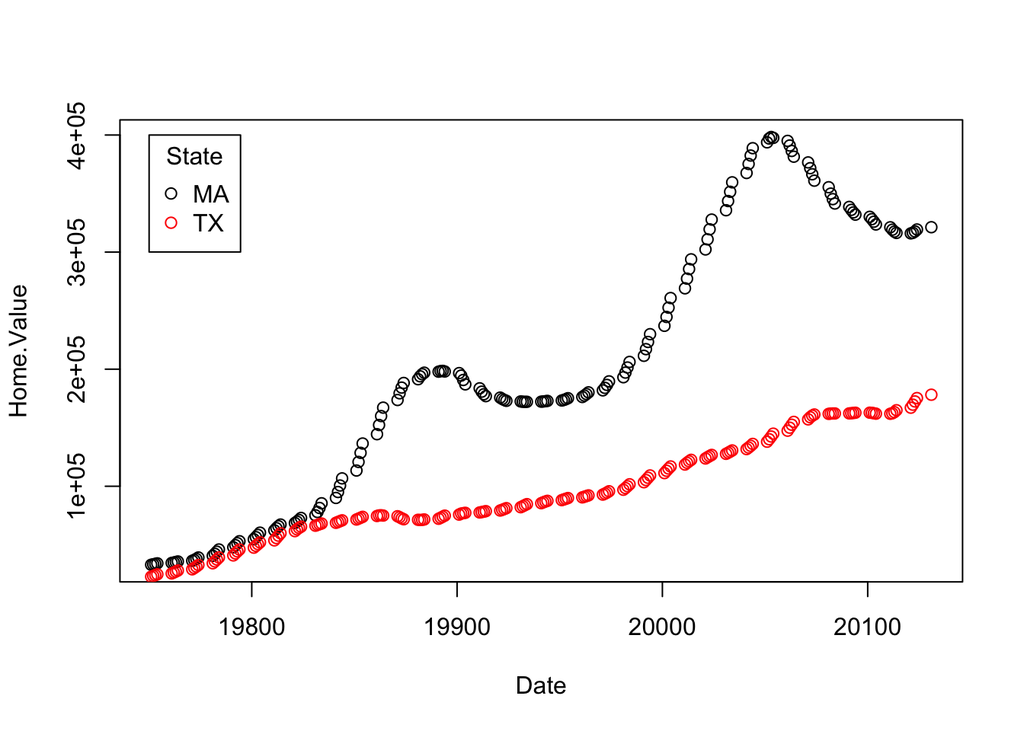

```r
  plot(Home.Value ~ Date,
       data=subset(housing, State == "MA"))
  points(Home.Value ~ Date, col="red",
         data=subset(housing, State == "TX"))
  legend(19750, 400000,
         c("MA", "TX"), title="State",
         col=c("black", "red"),
         pch=c(1, 1))
```

`ggplot2` colored scatter plot example:

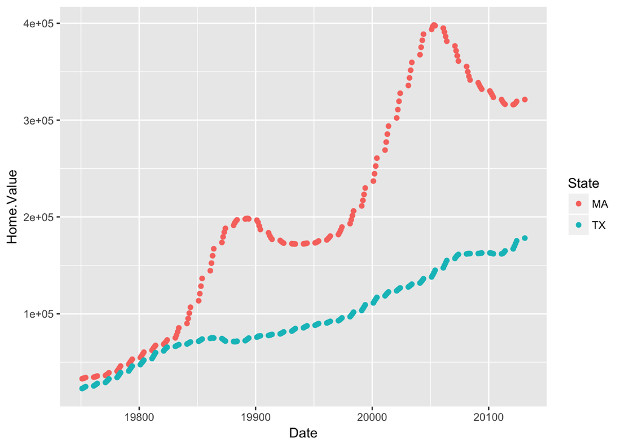

```r
  ggplot(subset(housing, State %in% c("MA", "TX")),
         aes(x=Date,
             y=Home.Value,
             color=State))+
    geom_point()
```

# Geometric Objects And Aesthetics

## Aesthetic Mapping

In ggplot land *aesthetic* means “something you can see”. Examples include:

- position (i.e., on the x and y axes)
- color (“outside” color)
- fill (“inside” color)
- shape (of points)
- linetype
- size

Aesthetic mappings are set with the `aes()` function.

## Geometic Objects (`geom`)

Geometric objects are the actual marks we put on a plot. Examples include:

- points (`geom_point`, for scatter plots, dot plots, etc)
- lines (`geom_line`, for time series, trend lines, etc)
- boxplot (`geom_boxplot`, for, well, boxplots!)

A plot must have at least one geom; there is no upper limit. You can add a geom to a plot using the `+` operator.

## Points (Scatterplot)

Now that we know about geometric objects and aesthetic mapping, we can make a ggplot. `geom_point` requires mappings for x and y, all others are optional.

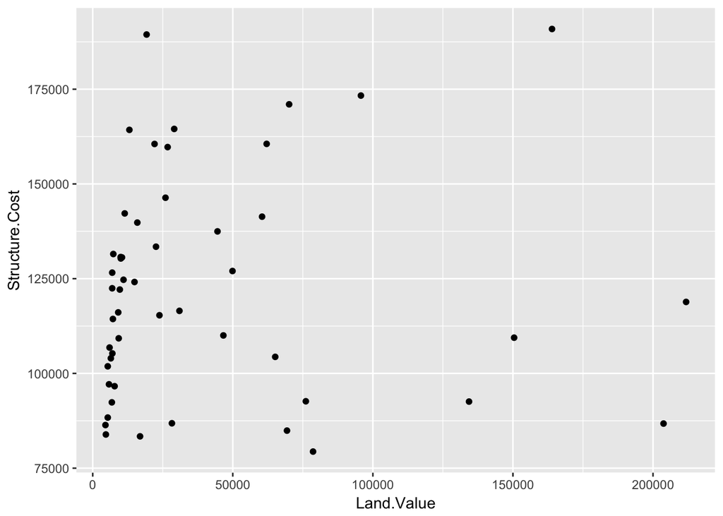

```r
  hp2001Q1 <- subset(housing, Date == 20011)
  ggplot(hp2001Q1,
         aes(y = Structure.Cost, x = Land.Value)) +
    geom_point()
```

## Lines (Prediction Line)

A plot constructed with `ggplot` can have more than one geom. In that case the mappings established in the `ggplot()` call are plot defaults that can be added to or overridden. Our plot could use a regression line:

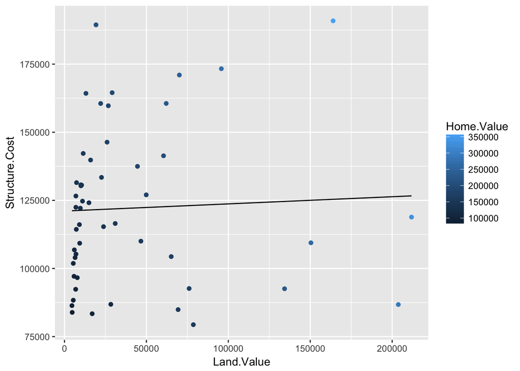

```r
  hp2001Q1$pred.SC <- predict(lm(Structure.Cost ~ Land.Value, data = hp2001Q1))

  ## Added mapping
  p1 <- ggplot(hp2001Q1, aes(x = Land.Value, y = Structure.Cost))
  ## Overridden
  p1 + geom_point(aes(color = Home.Value)) +
    geom_line(aes(y = pred.SC))
```

Smoothers ———

Not all geometric objects are simple shapes–the smooth geom includes a line and a ribbon.

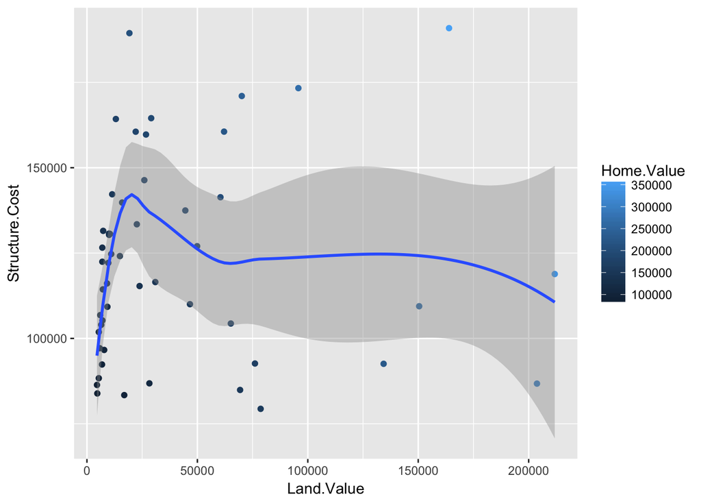

```r
  p1 +
    geom_point(aes(color = Home.Value)) +
    geom_smooth()
```

## Text (Label Points)

Each `geom` accepts a particualar set of mappings–for example `geom_text()` accepts a `labels` mapping.

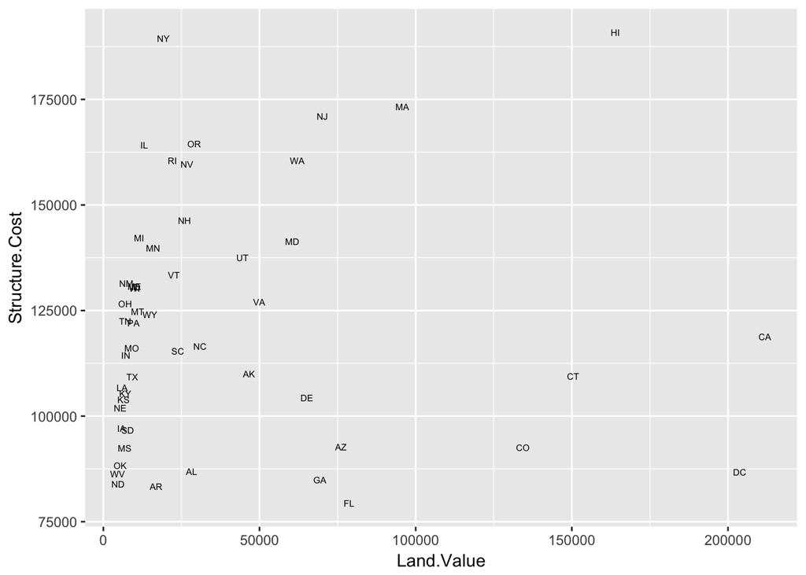

```r
  p1 +
    geom_text(aes(label=State), size = 2)
```

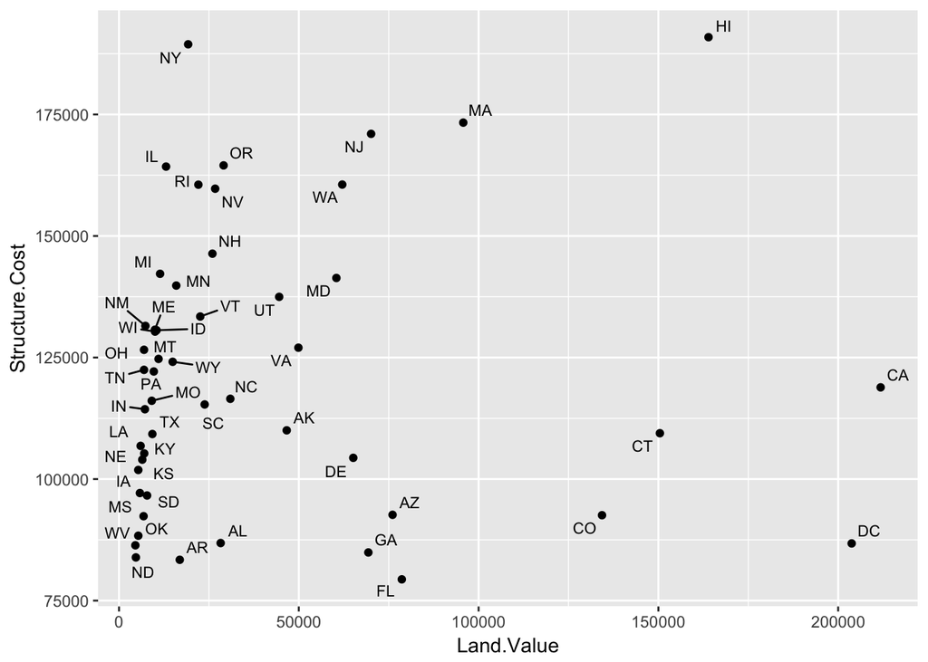

```r
  ##install.packages("ggrepel")
  library("ggrepel")
  p1 +
    geom_point() +
    geom_text_repel(aes(label=State), size = 3)
```

## Aesthetic Mapping VS Assignment

Note that variables are mapped to aesthetics with the `aes()` function, while fixed aesthetics are set outside the `aes()` call. This sometimes leads to confusion, as in this example:

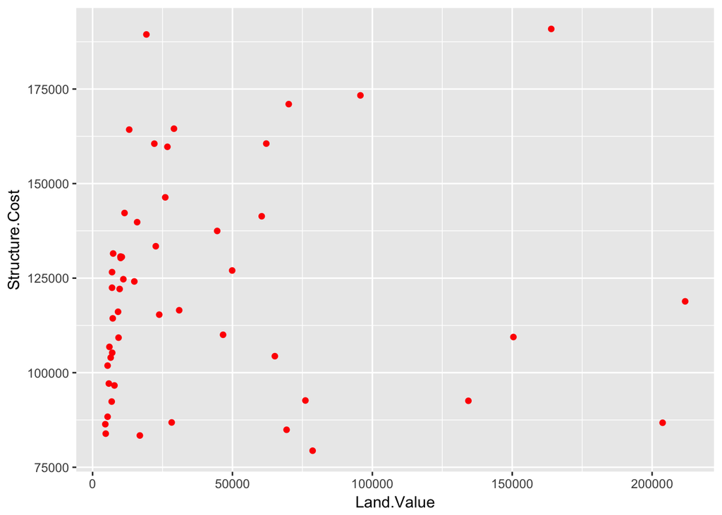

```r
## Incorrect
## p1 + geom_point(aes(size = 2)
## Correct
  p1 + geom_point(color="red") # this is fine -- all points red
```

## Mapping Variables To Other Aesthetics

Other aesthetics are mapped in the same way as x and y in the previous example.

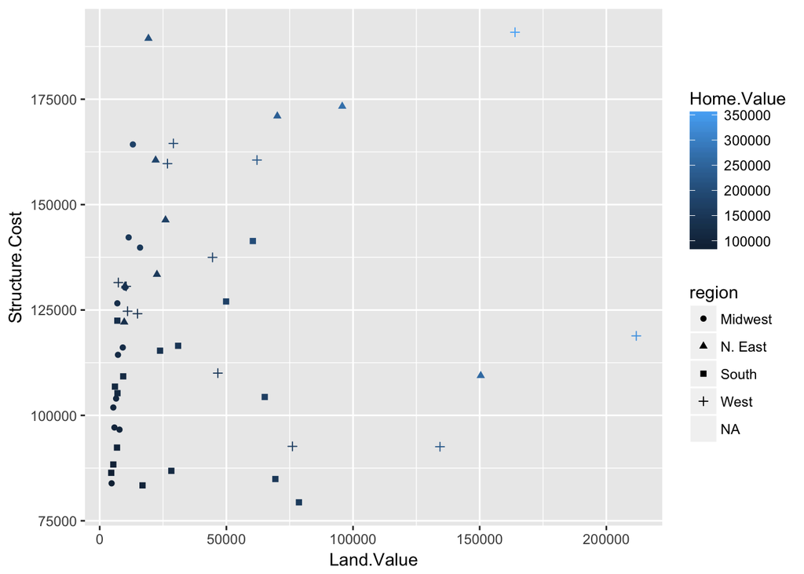

```r
  p1 + geom_point(aes(color=Home.Value, shape = region))
```

## Exercise I

The data for the exercises is available in the `dataSets/EconomistData.csv` file. Read it in with

```r
  dat <- read.csv("dataSets/EconomistData.csv")
```

These data consist of *Human Development Index* and *Corruption Perception Index* scores for several countries.

1. Create a scatter plot with CPI on the x axis and HDI on the y axis.
2. Color the points in the previous plot blue.
3. Color the points in the previous plot according to *Region*.
4. Create boxplots of CPI by Region
5. Overlay points on top of the box plots

## Solution

1. Create a scatter plot with CPI on the x axis and HDI on the y axis.

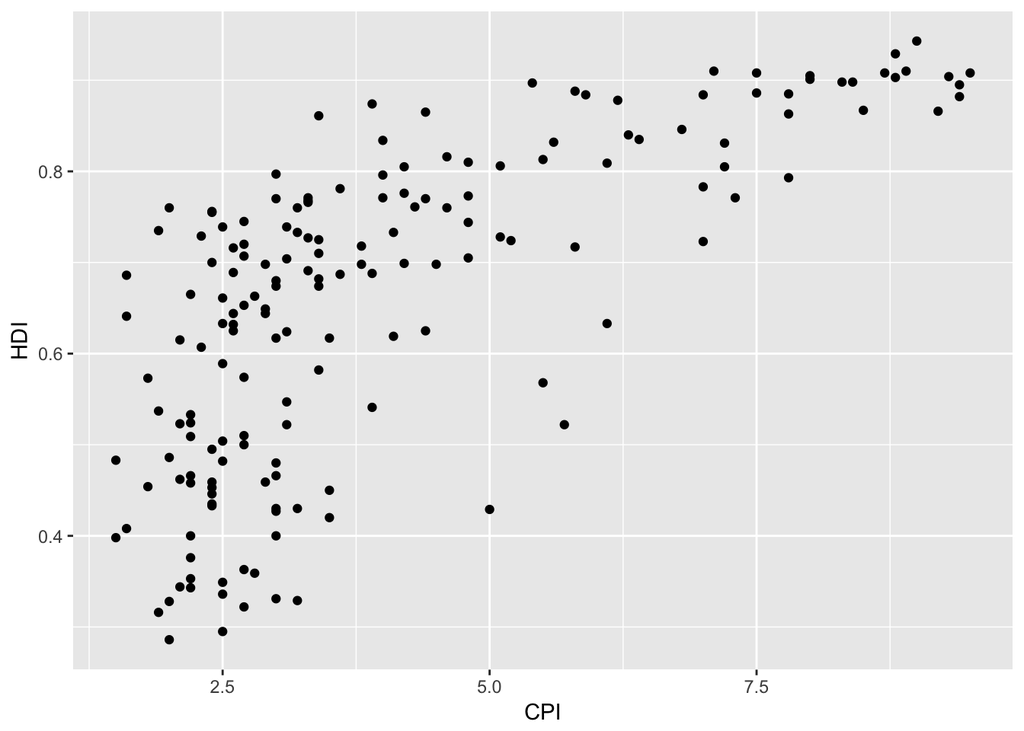

```r
p1 = ggplot(dat, aes(x = CPI, y = HDI))
p1 + geom_point()
```

2. Color the points in the previous plot blue.

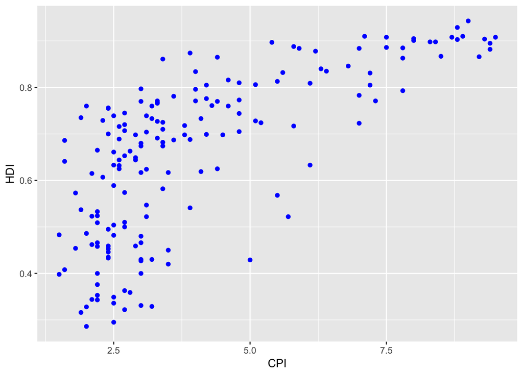

```r
p1 +  geom_point(color = "blue")
```

3. Color the points in the previous plot according to *Region*.

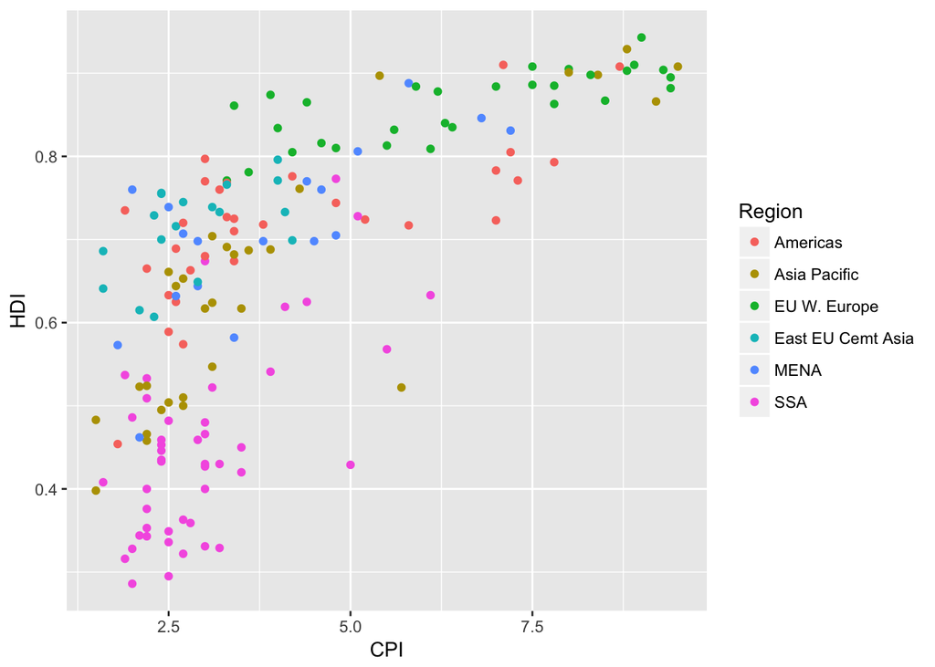

```r
p1+ geom_point(aes(color = Region))
```

4. Create boxplots of CPI by Region

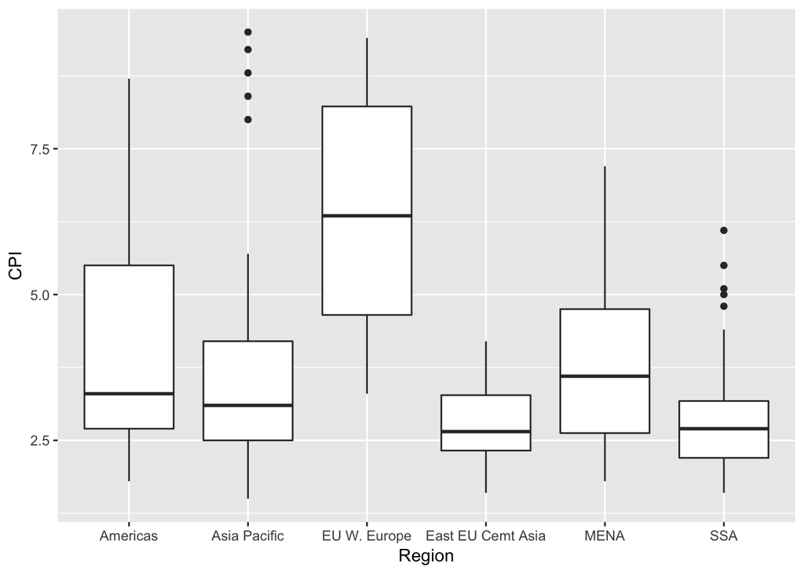

```r
ggplot(dat, aes(x = Region, y = CPI)) + geom_boxplot()
```

5. Overlay points on top of the box plots

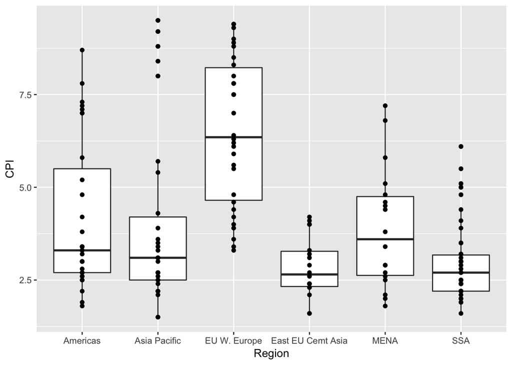

```r
ggplot(dat, aes(x = Region, y = CPI)) + geom_boxplot() +geom_point()
```

# Statistical Transformations

## Statistical Transformations

Some plot types (such as scatterplots) do not require transformations–each point is plotted at x and y coordinates equal to the original value. Other plots, such as boxplots, histograms, prediction lines etc. require statistical transformations:

- for a boxplot the y values must be transformed to the median and 1.5(IQR)
- for a smoother smother the y values must be transformed into predicted values

```r
  args(geom_histogram)
```

```
## function (mapping = NULL, data = NULL, stat = "bin", position = "stack",
##     ..., binwidth = NULL, bins = NULL, na.rm = FALSE, show.legend = NA,
##     inherit.aes = TRUE)
## NULL
```

```r
  args(stat_bin)
```

```
## function (mapping = NULL, data = NULL, geom = "bar", position = "stack",
##     ..., binwidth = NULL, bins = NULL, center = NULL, boundary = NULL,
##     breaks = NULL, closed = c("right", "left"), pad = FALSE,
##     na.rm = FALSE, show.legend = NA, inherit.aes = TRUE)
## NULL
```

## Setting Statistical Transformation Arguments

Arguments to `stat_` functions can be passed through `geom_` functions. This can be slightly annoying because in order to change it you have to first determine which stat the geom uses, then determine the arguments to that stat.

For example, here is the default histogram of Home.Value:

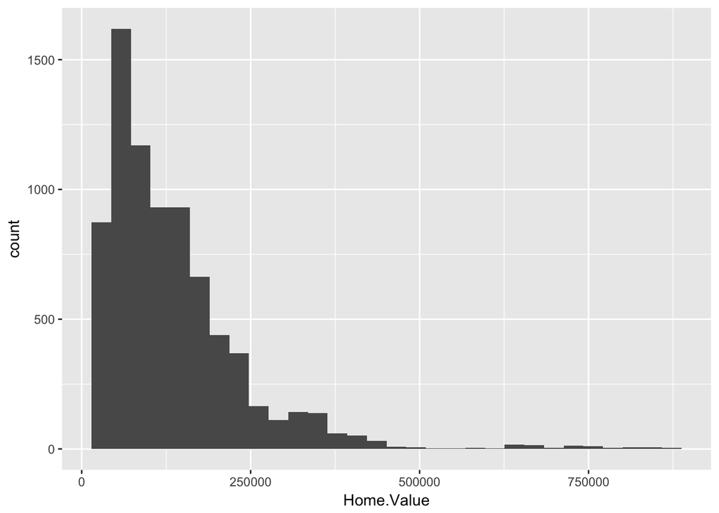

```r
  p2 <- ggplot(housing, aes(x = Home.Value))
  p2 + geom_histogram()
```

The binwidth looks reasonable by default, but we can change it by passing the `binwidth` argument to the `stat_bin` function:

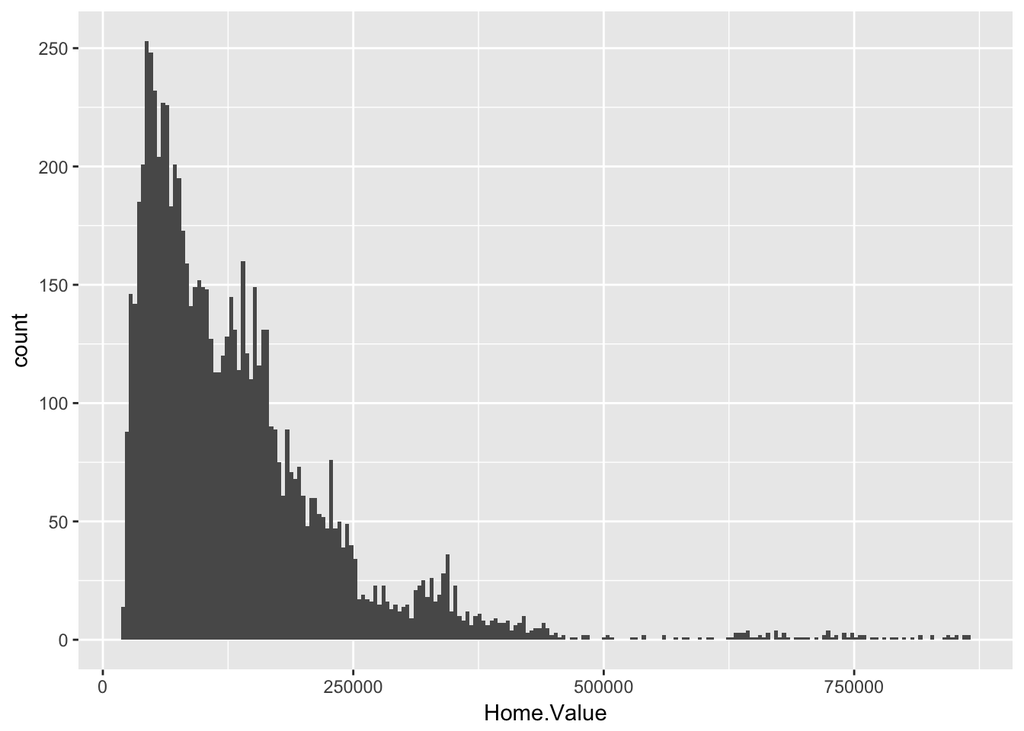

```r
  p2 + geom_histogram(stat = "bin", binwidth=4000)
```

## Changing The Statistical Transformation

Sometimes the default statistical transformation is not what you need. This is often the case with pre-summarized data:

```r
  housing.sum <- aggregate(housing["Home.Value"], housing["State"], FUN=mean)
  rbind(head(housing.sum), tail(housing.sum))
```

```
##    State Home.Value
## 1     AK  147385.14
## 2     AL   92545.22
## 3     AR   82076.84
## 4     AZ  140755.59
## 5     CA  282808.08
## 6     CO  158175.99
## 46    VA  155391.44
## 47    VT  132394.60
## 48    WA  178522.58
## 49    WI  108359.45
## 50    WV   77161.71
## 51    WY  122897.25
```

```r
## Already transformed
## ggplot(housing.sum, aes(x=State, y=Home.Value)) + geom_bar()
```

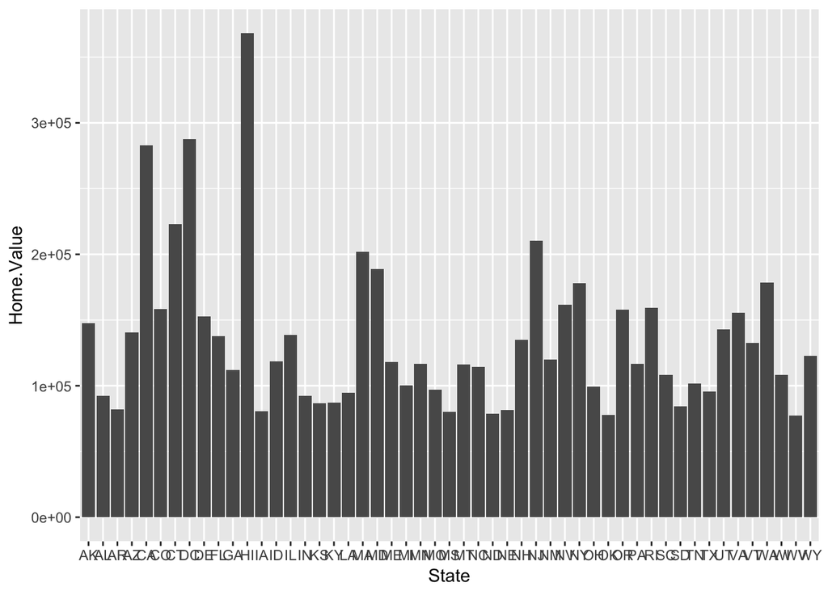

```r
  ggplot(housing.sum, aes(x=State, y=Home.Value)) + geom_bar(stat="identity")
```